# 1. 서론

1.1 연구 목적과 필요성

```
OECD 데이터에 따르면 한국의 자영업자 비율은 24.6%로, OECD 국가 중 6위를 차지하여 높은 수치와 순위를 보인다. 이러한 자영업 업종 중에서도 특히 선호도가 높은 것이 카페 업종으로, 근 몇 년간 창업률 1위를 유지하고 있다. 그러나 이러한 높은 선호에도 불구하고 카페 자영업의 생존율은 높지 않은데, KB금융지주 경영연구소가 발표한 ‘커피전문점 현황 및 시장 여건 분석’ 보고서에 따르면 커피 전문점의 폐업률은 14.1%에 달하며, 전체 폐업 매장의 52.6%는 영업 기간 3년을 채우지 못했다. 이러한 상황을 고려할 때 카페 업종에 있어 생존율을 높이고 경영 성과를 개선할 수 있는 전략의 수립은, 긍정적일 뿐 아니라 필요성이 유의미하게 높다고 할 수 있다.

선행 연구(장성수 외, 2016)에 의하면 온라인 리뷰는 상품의 질적 정보를 제공하며 소비자의 감정적 만족도를 반영한다. 따라서 온라인 리뷰를 분석하면 품질 평가에 있어 소비자들이 어떠한 요소를 중요시 했는지 확인할 수 있으며, 소비자들을 감정적으로 만족시킨 요인을 도출할 수 있다. 본 연구에서는 어떤 요인이 고객의 질적 감정적 만족도에 긍정적인 혹은 부정적인 영향을 미쳤는지 파악하여 카페 운영에 활용하고자 한다. 이를 통해 카페를 운영하는 자영업자들의 생존율을 높이고 경영 성과를 개선하며, 예비 카페 창업자들의 자생력을 제고시키고 경쟁력을 확보할 것을 기대한다.
```

1.2 연구 방향성

```
연구의 최종 목적은 카페의 운영 전략을 수립하여 실제 카페들의 경영 성과를 개선하는 것이다. 운영 전략은 실제 업장에서 다양한 배경을 가진 사장님들이 유연하게 활용할 수 있도록 이해와 적용이 쉬워야 한다. 복잡하고 난해한 전략은 보편성과 유연성을 갖지 못하며, 소수만 활용할 수 있기에 카페 업종의 전반적인 생존률 향상에 기여하지 못한다. 본 연구는 이러한 전제를 고려하여, 방법론으로 분석 과정과 결과를 직관적으로 이해하고 확인할 수 있는 잠재 디리클레 할당(Latent Dirichlet allocation, 이하 LDA) 토픽 모델링을 사용하려 한다.

LDA 토픽 모델링을 활용하면 두 가지 사안을 확인할 수 있다. 첫 번째는 ‘리뷰에서 어떤 주제들이 언급되었는가’이다. 이를 통해 리뷰어들이 관심을 갖는 사안들을 확인할 수 있다. 두 번째는 ‘리뷰에서 언급된 주제들 중 보다 중요한 주제는 무엇인가’이다. LDA 토픽 모델링을 통해 어떤 주제가 얼마나 많이 언급되었는가를 확인할 수 있기에, 이를 통해 주제들 간 우선순위를 확인할 수 있다. 즉, LDA를 통해 어떤 주제가 얼마나 중요한지 확인할 수 있으며, 본 연구에서는 이를 활용하여 카페 운영에 있어 어떤 요인의 추구에 집중하여야 하는지, 혹은 어떤 요인의 제거에 집중하여야 하는지 파악하고자 한다.
```

# 2. 연구 설계 및 진행

### 라이브러리 임포팅

!pip install xlrd

### 데이터 읽기

review_df=pd.read_excel("cafe_reviews_r.xlsx") review_df

review_df.info()

## EDA

! pip install https://github.com/pandas-profiling/pandas-profiling/archive/master.zip

import pandas_profiling  
profile = review_df.profile_report()  
profile

review_df = review_df.drop(labels=['store', 'description'],axis=1)

review_df

[figure not shown]

[figure not shown]

[figure not shown]

[figure not shown]

review_df.info()

## 전처리

### 결측치 확인

review_df.isnull().sum()

### 결측치 제거

review = review_df.dropna(axis = 0)  
review.isnull().sum()

### 결측치 확인

review_df.isnull().sum()

### konlpy 라이브러리 설치

!pip install konlpy

### 불용어 리스트 불러오기: park-gb github 참조, 일부 수정

stopword_list = pd.read_excel('/content/stopword_list.xlsx')  
stopword_list.head()

### 불용어 제거

[output not shown]

review_pos['reviews']=review_pos['reviews'].apply(lambda x: remove_stopword(x))  
review_neg['reviews']=review_neg['reviews'].apply(lambda x: remove_stopword(x))

review_pos = review_pos.drop(labels='rating',axis=1)  
review_neg = review_neg.drop(labels='rating',axis=1)

review_pos

## 긍정 리뷰 토픽 모델링 및 시각화

### Topic Modeling

from gensim import corpora  
dictionary = corpora.Dictionary(review_pos['reviews'])  
corpus = [dictionary.doc2bow(text) for text in review_pos['reviews']]  
print(corpus[1])  
print(dictionary[1])  
len(dictionary)

### 주제 일관성, 높을수록 좋음

import gensim  
import matplotlib.pyplot as plt  
from gensim.models import CoherenceModel

coherence_values=[]  
for i in range(2,30):

```
ldamodel=gensim.models.ldamodel.LdaModel(corpus, num_topics=i, id2word=dictionary)
coherence_model_lda =CoherenceModel(model=ldamodel, texts=review_pos['reviews'], dictionary = dictionary,topn=10)
coherence_lda=coherence_model_lda.get_coherence()
coherence_values.append(coherence_lda)
```

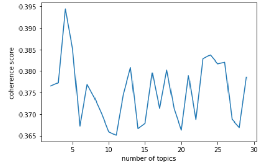

### 모델링

import gensim  
NUM_TOPICS = 9 # 9개 토픽  
ldamodel = gensim.models.ldamodel.LdaModel(corpus, num_topics = NUM_TOPICS, id2word=dictionary, passes=25)  
topics = ldamodel.print_topics(num_words=5)  
for topic in topics:

```
print(topic)
```

print(ldamodel.print_topics())

!pip install pyLDAvis

### 긍정 리뷰 토픽 가시화

import pyLDAvis  
import pyLDAvis.gensim_models as gensimvis  
pyLDAvis.enable_notebook()

prepared_data = gensimvis.prepare(ldamodel, corpus, dictionary)  
prepared_data

@ Sievert & Shirley (2014) 연구에 따르면, Relevance 값은 0.6이 가장 효과적인 것으로 알려져 있음

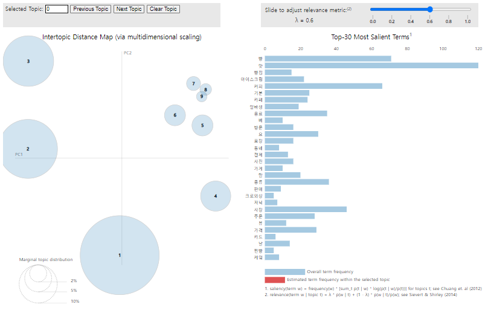